# HW3. Air Quality Risk Assessment

Author

Katerina Bischel

Published

May 12, 2026

## Setup

```r
library(tidyverse)

# Reproducible sampling
set.seed(262)
```

## Part 1. Build the Dataset

I simulate one calendar year of daily PM2.5 readings from a single monitoring station. PM2.5 is drawn from a normal distribution and truncated at zero (concentrations cannot be negative).

**Distribution justification.** Typical urban daily PM2.5 in U.S. cities sits roughly in the 5–25 µg/m³ range on normal days, with episodic spikes well above that during inversions, wildfire smoke events, and heavy traffic periods. The current U.S. EPA 24-hour NAAQS is 35 µg/m³, the revised (2024) annual NAAQS is 9 µg/m³, and the WHO 24-hour guideline is 15 µg/m³. I chose `rnorm(n = 365, mean = 15, sd = 12)` truncated at zero, which centers daily concentrations modestly above the EPA annual standard — defensible for a moderately polluted urban monitoring site — and uses a standard deviation large enough to produce a believable right tail of “unhealthy” days (roughly 10–20 per year) interspersed in a year that is dominated by “good” and “moderate” days. A pure normal under-represents the very long tail of real-world wildfire or stagnation events, but it is the closest fit among the in-class choices (`runif`, `rnorm`, `rpois`) and produces qualitatively realistic counts across the three EPA risk categories.

```r
n_days <- 365

# Generate PM2.5 and truncate at zero (negative concentrations are non-physical)
pm25_raw <- rnorm(n_days, mean = 15, sd = 12)
pm25     <- pmax(pm25_raw, 0)

# Assign seasons by day-of-year range
season_levels <- c("winter", "spring", "summer", "fall")
day <- 1:n_days
season_chr <- dplyr::case_when(
  day <= 90               ~ "winter",
  day >= 91  & day <= 180 ~ "spring",
  day >= 181 & day <= 270 ~ "summer",
  day >= 271              ~ "fall"
)

aq <- data.frame(
  day    = day,
  pm25   = pm25,
  season = factor(season_chr, levels = season_levels),
  risk   = NA_character_,
  stringsAsFactors = FALSE
)

str(aq)
```

```
'data.frame':   365 obs. of  4 variables:
 $ day   : int  1 2 3 4 5 6 7 8 9 10 ...
 $ pm25  : num  10.73 11.36 1.73 5.24 24.31 ...
 $ season: Factor w/ 4 levels "winter","spring",..: 1 1 1 1 1 1 1 1 1 1 ...
 $ risk  : chr  NA NA NA NA ...
```

```r
head(aq)
```

```
  day      pm25 season risk
1   1 10.732164 winter <NA>
2   2 11.363383 winter <NA>
3   3  1.733150 winter <NA>
4   4  5.239702 winter <NA>
5   5 24.308507 winter <NA>
6   6 20.194131 winter <NA>
```

```r
summary(aq$pm25)
```

```
   Min. 1st Qu.  Median    Mean 3rd Qu.    Max.
  0.000   5.927  15.975  16.058  23.891  54.992
```

## Part 2. Classify Risk with a For Loop

The same `for` loop does two things:

1. Fills `risk` based on EPA-style PM2.5 thresholds (good < 12, moderate 12–35.4, unhealthy > 35.4).
2. Tracks the longest consecutive run of `"unhealthy"` days by comparing each row to the previous row’s classification.

```r
# Initialize trackers for the streak
current_streak       <- 0
max_unhealthy_streak <- 0

for (i in seq_len(nrow(aq))) {

  # --- 1. Classify risk for day i -------------------------------------------
  if (aq$pm25[i] < 12) {
    aq$risk[i] <- "good"
  } else if (aq$pm25[i] <= 35.4) {
    aq$risk[i] <- "moderate"
  } else {
    aq$risk[i] <- "unhealthy"
  }

  # --- 2. Track consecutive "unhealthy" streak ------------------------------
  # Check the previous row's risk to decide whether to extend or restart.
  if (aq$risk[i] == "unhealthy") {
    if (i == 1 || aq$risk[i - 1] != "unhealthy") {
      current_streak <- 1            # new streak begins
    } else {
      current_streak <- current_streak + 1   # extend existing streak
    }
    if (current_streak > max_unhealthy_streak) {
      max_unhealthy_streak <- current_streak
    }
  } else {
    current_streak <- 0              # streak broken
  }
}

# Make risk an ordered factor for nicer plotting/tables
aq$risk <- factor(aq$risk, levels = c("good", "moderate", "unhealthy"))

table(aq$risk)
```

```
     good  moderate unhealthy
      150       198        17
```

```r
sprintf("Longest consecutive unhealthy streak: %d days", max_unhealthy_streak)
```

```
[1] "Longest consecutive unhealthy streak: 2 days"
```

## Part 3. Seasonal Summary with a For Loop

Count the number of `"unhealthy"` days in each season using a `for` loop. Results are stored in a named integer vector and then converted to a tidy data frame for display.

```r
unhealthy_by_season <- setNames(integer(length(season_levels)), season_levels)

for (s in season_levels) {
  unhealthy_by_season[s] <- sum(aq$season == s & aq$risk == "unhealthy")
}

unhealthy_by_season
```

```
winter spring summer   fall
     4      4      6      3
```

```r
# Tidy version for the report
seasonal_summary <- data.frame(
  season         = factor(season_levels, levels = season_levels),
  unhealthy_days = as.integer(unhealthy_by_season)
)
seasonal_summary
```

```
  season unhealthy_days
1 winter              4
2 spring              4
3 summer              6
4   fall              3
```

## Part 4. Visualize and Report

Both plot titles are built with `sprintf()` and include the `max_unhealthy_streak` value computed in Part 2.

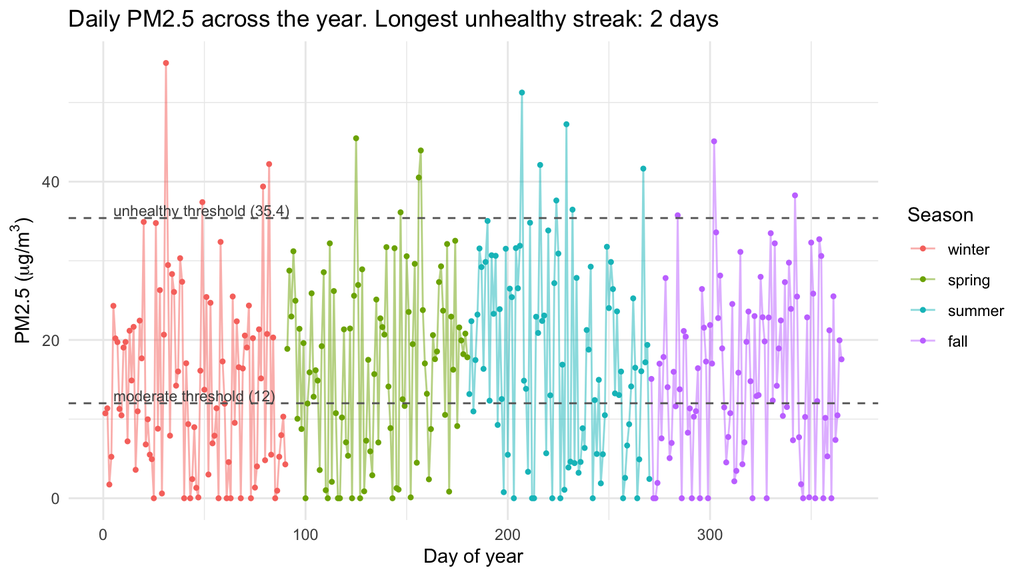

```r
title_ts <- sprintf(
  "Daily PM2.5 across the year. Longest unhealthy streak: %d days",
  max_unhealthy_streak
)

ggplot(aq, aes(x = day, y = pm25, color = season)) +
  geom_line(alpha = 0.5) +
  geom_point(size = 0.9) +
  geom_hline(yintercept = 12,   linetype = "dashed", color = "grey40") +
  geom_hline(yintercept = 35.4, linetype = "dashed", color = "grey40") +
  annotate("text", x = 5, y = 13,   label = "moderate threshold (12)",
           hjust = 0, size = 3, color = "grey30") +
  annotate("text", x = 5, y = 36.4, label = "unhealthy threshold (35.4)",
           hjust = 0, size = 3, color = "grey30") +
  labs(title = title_ts,
       x = "Day of year",
       y = expression("PM2.5 ("*mu*"g/m"^3*")"),
       color = "Season") +
  theme_minimal()
```

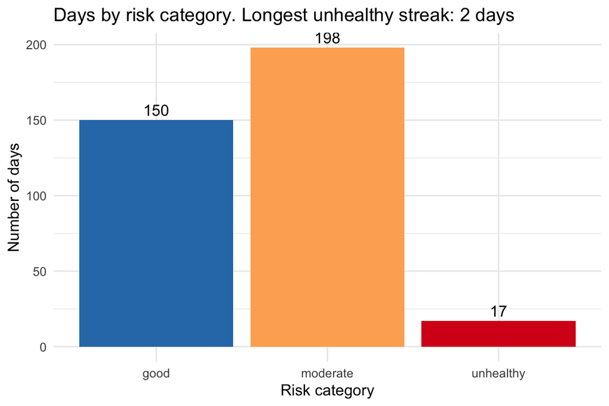

```r
title_bar <- sprintf(
  "Days by risk category. Longest unhealthy streak: %d days",
  max_unhealthy_streak
)

ggplot(aq, aes(x = risk, fill = risk)) +
  geom_bar() +
  geom_text(stat = "count", aes(label = after_stat(count)), vjust = -0.4) +
  scale_fill_manual(values = c(good      = "#2c7bb6",
                               moderate  = "#fdae61",
                               unhealthy = "#d7191c")) +
  labs(title = title_bar,
       x = "Risk category",
       y = "Number of days") +
  theme_minimal() +
  theme(legend.position = "none")
```

### Management summary

Over the simulated year, this monitoring station recorded 150 days classified as “good” (PM2.5 < 12 µg/m³), 198 “moderate” days (12–35.4 µg/m³), and 17 “unhealthy” days exceeding the EPA 24-hour standard of 35.4 µg/m³. The longest consecutive run of unhealthy days was 2. Unhealthy days were not evenly distributed across the calendar — **summer** carried the largest share with 6 unhealthy days, a pattern consistent with seasonal drivers such as temperature inversions, residential wood smoke, agricultural burning, or wildfire smoke (depending on the season). Although most days fell within acceptable ranges, the unhealthy episodes matter disproportionately for public health: even a short multi-day streak substantially raises cumulative exposure for sensitive populations (children, older adults, and people with asthma or cardiovascular disease). From a policy standpoint, the data argue for (1) season-targeted advisories and burn-day restrictions during the highest-risk months, (2) clear public-facing alerts triggered whenever a multi-day unhealthy streak is forecast, and (3) sustained monitoring so trends in streak length and seasonal share can be tracked year over year and compared against intervention efforts.